# SEV_PlantBiomassRegressions_BurnEffects

AJ

2017-09-07 18:27:32

## Background

Several long-term studies at the Sevilleta LTER measure net primary production (NPP) across ecosystems and treatments. Net primary production is a fundamental ecological variable that quantifies rates of carbon consumption and fixation. Estimates of NPP are important in understanding energy flow at a community level as well as spatial and temporal responses to a range of ecological processes. Above-ground net primary production (ANPP) is the change in plant biomass, including loss to death and decomposition, over a given period of time. To measure this change, vegetation variables, including species composition and the cover and height of individuals, are sampled up to three times yearly (winter, spring, and fall) at permanent plots within a study site. Sevilleta LTER dataset 157 includes cover, height, and dry biomass measurements obtained through destructive harvesting. These species are always harvested from habitat comparable to the plots in which they were recorded.

## Purpose

The following R code utilizes volume (cover x height) and weight data from Sev dataset 157 to create regressions which can be used to estimate seasonal biomass for plant species across the Sevilleta.

This script specifically tests for species-specific burn effects on volume:mass relationships or allometries. As such, we will only be looking at species collected at Site L (Deep Well area) collections which were initiated in 2004.

### Step 1: Preparing the data

SEV dataset 157 (version 20161218) is used here.

The data look like this:

|  | Year | Season | Date | Site | Treatment | kartez | Cover | Height | Live_Weight | Volume | SinceBurn |
| --- | --- | --- | --- | --- | --- | --- | --- | --- | --- | --- | --- |
| 11641 | 2004 | 3 | 9/23/2004 | L | C | ALIN | 0.01 | 1 | 0.01 | 0.01 | 24 |
| 11642 | 2004 | 3 | 9/23/2004 | L | C | ALIN | 0.01 | 1 | 0.01 | 0.01 | 24 |
| 11643 | 2004 | 3 | 9/23/2004 | L | C | ALIN | 0.05 | 3 | 0.11 | 0.15 | 24 |
| 11644 | 2004 | 3 | 9/23/2004 | L | C | ALIN | 0.10 | 7 | 0.04 | 0.70 | 24 |
| 11645 | 2004 | 3 | 9/23/2004 | L | C | ALIN | 0.25 | 8 | 0.21 | 2.00 | 24 |
| 11646 | 2004 | 3 | 9/23/2004 | L | C | ALIN | 0.50 | 4 | 0.32 | 2.00 | 24 |

```r
# Create full matrix for model output
model.coefs.all <- data.frame(
  kartez = as.factor(NA),
  Year = as.factor(NA),
  Season = as.factor(NA),
  Treatment = as.factor(NA),
  Beta.Volume = NA,
  SE = NA,
  p.value = NA,
  AdjR = NA)
```

We will consider the following species:

### Species: ARPUP6

Number of observations: 155  
Years collected: 2004 - 2011  
Burn treatments considered: 1 - 27  
*Size range*:

- Cover: 0.01 - 6
- Height: 1 - 24
- Volume: 0.04 - 102
- Weight: 0.01 - 52.14

Model: Live_Weight ~ 0 + Volume + Season + Volume x SinceBurn

- Volume main effect: 3.636273e-22
- Season main effect: 7.890787e-06
- Volume x Treatment interaction: 0.01604624

Model residuals. Variables with non-significant interactions not shown.

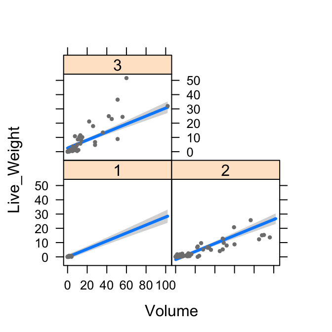

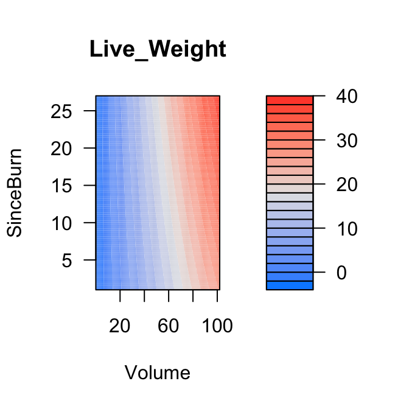

### Species: BOBA2

Number of observations: 61  
Years collected: 2004 - 2014  
Burn treatments considered: 4 - 24  
*Size range*:

- Cover: 0.01 - 10
- Height: 2 - 28
- Volume: 0.04 - 230
- Weight: 0.01 - 8.89

Model: Live_Weight ~ 0 + Volume + Volume x SinceBurn

- Volume main effect: 2.380359e-28
- Season main effect: NA
- Volume x Treatment interaction: 1.197009e-13

Model residuals. Variables with non-significant interactions not shown.

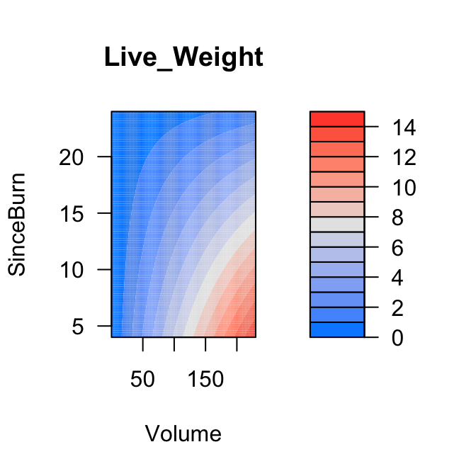

### Species: BOER4

Number of observations: 722  
Years collected: 2004 - 2016  
Burn treatments considered: 0 - 29  
*Size range*:

- Cover: 0.01 - 30
- Height: 1 - 151
- Volume: 0.01 - 1140
- Weight: 0.01 - 159.49

Model: Live_Weight ~ 0 + Volume + Season + Volume x SinceBurn

- Volume main effect: 7.124518e-61
- Season main effect: 0.0001086871
- Volume x Treatment interaction: 0.8530481

Model residuals. Variables with non-significant interactions not shown.

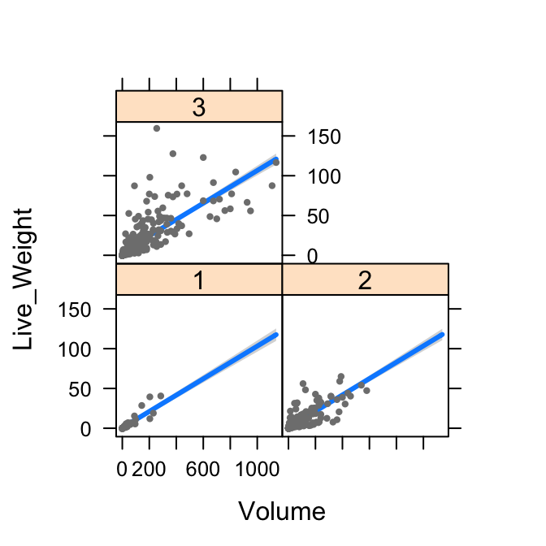

### Species: BOGR2

Number of observations: 724  
Years collected: 2004 - 2016  
Burn treatments considered: 0 - 29  
*Size range*:

- Cover: 0.01 - 30
- Height: 1 - 51
- Volume: 0.01 - 870
- Weight: 0.01 - 86.79

Model: Live_Weight ~ 0 + Volume + Season + Volume x SinceBurn

- Volume main effect: 5.574601e-63
- Season main effect: 5.354417e-12
- Volume x Treatment interaction: 0.576007

Model residuals. Variables with non-significant interactions not shown.

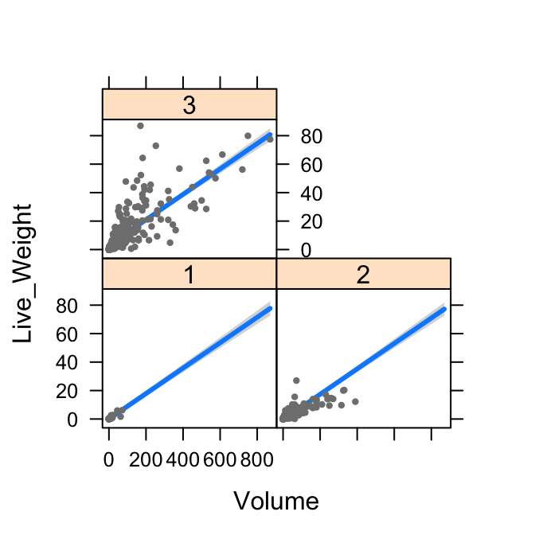

### Species: LATR2L

Number of observations: 685  
Years collected: 2004 - 2013  
Burn treatments considered: 0 - 29  
*Size range*:

- Cover: 0.01 - 35
- Height: 1 - 71
- Volume: 0.01 - 1995
- Weight: 0.01 - 144.91

Model: Live_Weight ~ 0 + Volume + Season + Volume x SinceBurn

- Volume main effect: 1.746783e-169
- Season main effect: 0.1748547
- Volume x Treatment interaction: 6.103251e-09

Model residuals. Variables with non-significant interactions not shown.

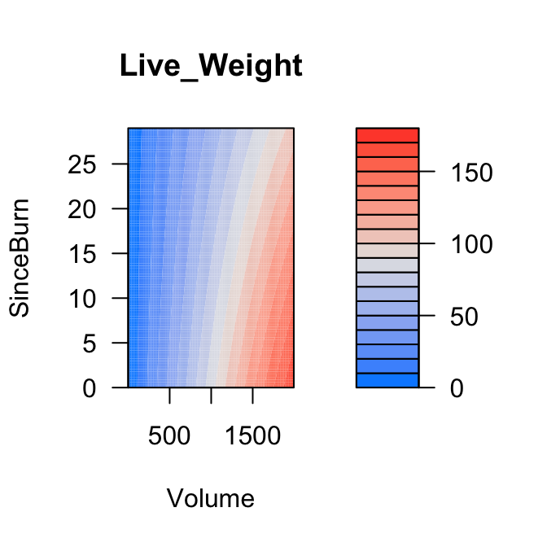

### Species: LATR2T

Number of observations: 564  
Years collected: 2005 - 2013  
Burn treatments considered: 0 - 29  
*Size range*:

- Cover: 0.01 - 35
- Height: 2 - 62
- Volume: 0.02 - 1995
- Weight: 0.01 - 219.44

Model: Live_Weight ~ 0 + Volume + Season + Volume x SinceBurn

- Volume main effect: 5.00999e-176
- Season main effect: 0.005871976
- Volume x Treatment interaction: 0.02108201

Model residuals. Variables with non-significant interactions not shown.

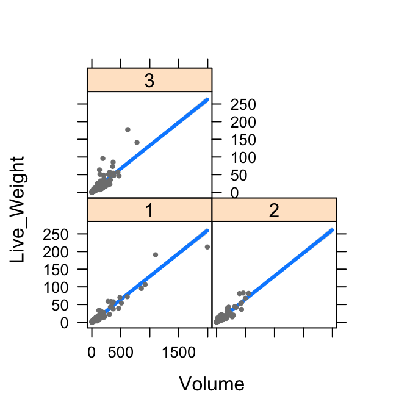

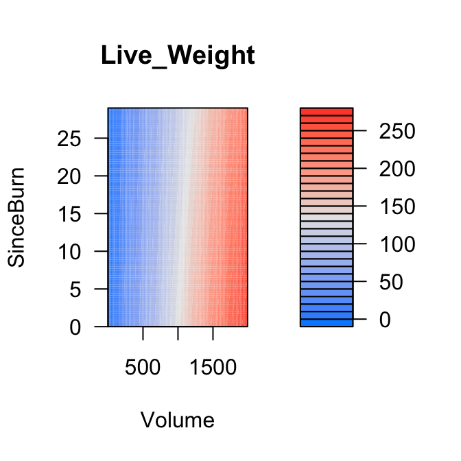

### Species: PLJA

Number of observations: 679  
Years collected: 2004 - 2016  
Burn treatments considered: 0 - 29  
*Size range*:

- Cover: 0.01 - 25
- Height: 1 - 57
- Volume: 0.01 - 975
- Weight: 0.01 - 75.65

Model: Live_Weight ~ 0 + Volume + Season + Volume x SinceBurn

- Volume main effect: 3.220731e-125
- Season main effect: 0.1030971
- Volume x Treatment interaction: 2.095245e-07

Model residuals. Variables with non-significant interactions not shown.

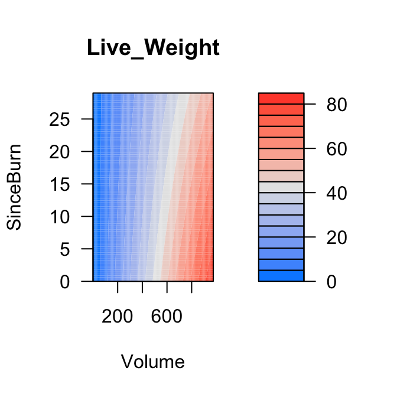

### Species: SPCO4

Number of observations: 225  
Years collected: 2006 - 2014  
Burn treatments considered: 1 - 28  
*Size range*:

- Cover: 0.05 - 15
- Height: 1 - 50
- Volume: 0.05 - 630
- Weight: 0.01 - 98.92

Model: Live_Weight ~ 0 + Volume + Volume x SinceBurn

- Volume main effect: 2.06761e-25
- Season main effect: NA
- Volume x Treatment interaction: 2.589696e-10

Model residuals. Variables with non-significant interactions not shown.

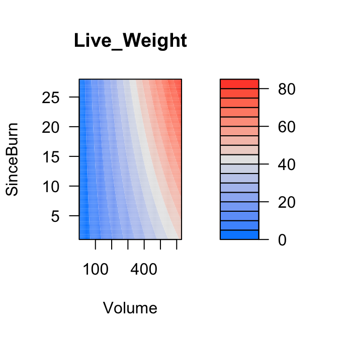